# Bioinformatics_class_7

Caroline Iacuaniello

April 25, 2018

# Functions again

We can source any file of R code with the ‘source’ () function.

```r
source("http://tinyurl.com/rescale-R")
```

Lets make sure things are here

```r
ls()
```

```
##  [1] "both_na"         "both_na2"        "both_na3"
##  [4] "df1"             "df2"             "df3"
##  [7] "gene_intersect"  "gene_intersect2" "gene_intersect3"
## [10] "gene_intersect4" "rescale"         "rescale2"
```

check rescale function is working

```r
rescale(1:10)
```

```
##  [1] 0.0000000 0.1111111 0.2222222 0.3333333 0.4444444 0.5555556 0.6666667
##  [8] 0.7777778 0.8888889 1.0000000
```

```r
rescale( c(1:10, "string"))
```

```r
rescale2( c(1:10, "string"))
```

## Function for finding missing values in two datasets

Write a ‘both_na()’ function to do this

```r
# Lets define an example x and y
x <- c( 1, 2, NA, 3, NA)
y <- c(NA, 3, NA, 3, 4)
is.na(x)
```

```
## [1] FALSE FALSE  TRUE FALSE  TRUE
```

```r
is.na(y)
```

```
## [1]  TRUE FALSE  TRUE FALSE FALSE
```

```r
which(is.na(x))
```

```
## [1] 3 5
```

```r
which(!is.na(x))
```

```
## [1] 1 2 4
```

```r
(z <- 5)
```

```
## [1] 5
```

```r
if(z <- 5) {
  print("more")
} else{print("less")}
```

```
## [1] "more"
```

To count, false = 0, true = 1

```r
sum(is.na(x))
```

```
## [1] 2
```

```r
is.na(x)
```

```
## [1] FALSE FALSE  TRUE FALSE  TRUE
```

```r
is.na(y)
```

```
## [1]  TRUE FALSE  TRUE FALSE FALSE
```

```r
is.na(x) & is.na(y)
```

```
## [1] FALSE FALSE  TRUE FALSE FALSE
```

The & symbol combines

```r
sum(is.na(x) & is.na(y))
```

```
## [1] 1
```

```r
which(is.na(x) & is.na(y))
```

```
## [1] 3
```

My first function can start from this snippet.

```r
both_na <- function(x,y) {sum(is.na(x) & is.na(y))}
```

Test it!

```r
both_na(x,y)
```

```
## [1] 1
```

```r
x <- c(NA, NA, NA)
y1 <- c( 1, NA, NA)
y2 <- c( 1, NA, NA, NA)
both_na(x, y1)
both_na3(x, y2)
```

```r
x <- c( 1, 2, NA, 3, NA)
y <- c(NA, 3, NA, 3, 4)
ans <- both_na3(x,y)
```

```
## Found 1 NA's at position(s):3
```

```r
ans$which
```

```
## [1] 3
```

# Start with a simple version of the problem

```r
x <- df1$IDs
y <- df2$IDs
x
```

```
## [1] "gene1" "gene2" "gene3"
```

```r
y
```

```
## [1] "gene2" "gene4" "gene3" "gene5"
```

We can try the ‘intersect()’ function and the “%in%” functions.

```r
intersect(x,y)
```

```
## [1] "gene2" "gene3"
```

intersect not very useful, gave answer but no more info

```r
x %in% y
```

```
## [1] FALSE  TRUE  TRUE
```

This is checking if the first thing in x is in y, etc. Try for things in y in x.

```r
y %in% x
```

```
## [1]  TRUE FALSE  TRUE FALSE
```

```r
x[x %in% y]
```

```
## [1] "gene2" "gene3"
```

```r
y[y %in% x]
```

```
## [1] "gene2" "gene3"
```

Now try the cbind() function. binds inputs as columns of new matrix. These results yield intersects. Use logical output in ‘%in%’ to get at our matching data.

```r
x[x %in% y]
```

```
## [1] "gene2" "gene3"
```

```r
y[y %in% x]
```

```
## [1] "gene2" "gene3"
```

Lets put these together as columns of a matrix

```r
cbind(x[x %in% y],
y[y %in% x])
```

```
##      [,1]    [,2]
## [1,] "gene2" "gene2"
## [2,] "gene3" "gene3"
```

```r
cbind( c("Hello", "Help"), c("Please", "me"))
```

```
##      [,1]    [,2]
## [1,] "Hello" "Please"
## [2,] "Help"  "me"
```

```r
rbind( c("Hello", "Help"), c("Please", "me"))
```

```
##      [,1]     [,2]
## [1,] "Hello"  "Help"
## [2,] "Please" "me"
```

# Make a gene intersect function

```r
gene_intersect <- function(x, y) {
 cbind( x[ x %in% y ], y[ y %in% x ] )
}

#Testing
gene_intersect(x,y)
```

```
##      [,1]    [,2]
## [1,] "gene2" "gene2"
## [2,] "gene3" "gene3"
```

Try with data frame input

```r
gene_intersect2(df1,df2)
```

```
##     IDs exp df2[df2$IDs %in% df1$IDs, "exp"]
## 2 gene2   1                               -2
## 3 gene3   1                                1
```

Looks good, this is skateboard :)

```r
gene_intersect3(df1, df2)
```

```
##     IDs exp exp2
## 2 gene2   1   -2
## 3 gene3   1    1
```

Works, but code is ugly. Make code tighter.

```r
gene_intersect4(df1,df2)
```

```
##     IDs exp exp2
## 2 gene2   1   -2
## 3 gene3   1    1
```

Test against some data frame with gene 2 found twice

```r
gene_intersect4(df1, df3)
```

```
## Warning in data.frame(..., check.names = FALSE): row names were found from
## a short variable and have been discarded
```

```
##     IDs exp exp2
## 1 gene2   1   -2
## 2 gene2   1   NA
```

GEts a warning message but overall works.

Lets use ‘merge()’ function for this…

```r
merge(df1, df2, by="IDs")
```

```
##     IDs exp.x exp.y
## 1 gene2     1    -2
## 2 gene3     1     1
```

```r
 source("https://bioconductor.org/biocLite.R")
```

```
## Bioconductor version 3.6 (BiocInstaller 1.28.0), ?biocLite for help
```

```
## A new version of Bioconductor is available after installing the most
##   recent version of R; see http://bioconductor.org/install
```

```r
 biocLite("phyloseq")
```

```
## BioC_mirror: https://bioconductor.org
```

```
## Using Bioconductor 3.6 (BiocInstaller 1.28.0), R 3.4.4 (2018-03-15).
```

```
## Installing package(s) 'phyloseq'
```

[output not shown]

[output not shown]

```r
library("phyloseq"); packageVersion("phyloseq")
```

```
## [1] '1.22.3'
```

```r
# Create a pretend OTU table that you read from a file, called otumat
otumat = matrix(sample(1:100, 100, replace = TRUE), nrow = 10, ncol = 10)
otumat
```

```
##       [,1] [,2] [,3] [,4] [,5] [,6] [,7] [,8] [,9] [,10]
##  [1,]   66   69   49   67   57   69   14   88   48    13
##  [2,]   70   41   47   62    4   91   81   70   60    21
##  [3,]   92   85   40    9   60  100   68   36   96    14
##  [4,]   55    8   96   95   76   55   91   14   35    32
##  [5,]   46   64   74   47   18   82   32   93   23     5
##  [6,]   26   87   25   38   50   49   18   23    1    93
##  [7,]   64   66   39   82   89   76   55   95   52    56
##  [8,]   68   80   65   85   82   37   48   17   64    82
##  [9,]   74   75   99    2   71   48   86   95   26    19
## [10,]   87   47   71    3   86   47    1   17   93    46
```

```r
rownames(otumat) <- paste0("OTU", 1:nrow(otumat))
colnames(otumat) <- paste0("Sample", 1:ncol(otumat))
otumat
```

```
##       Sample1 Sample2 Sample3 Sample4 Sample5 Sample6 Sample7 Sample8
## OTU1       66      69      49      67      57      69      14      88
## OTU2       70      41      47      62       4      91      81      70
## OTU3       92      85      40       9      60     100      68      36
## OTU4       55       8      96      95      76      55      91      14
## OTU5       46      64      74      47      18      82      32      93
## OTU6       26      87      25      38      50      49      18      23
## OTU7       64      66      39      82      89      76      55      95
## OTU8       68      80      65      85      82      37      48      17
## OTU9       74      75      99       2      71      48      86      95
## OTU10      87      47      71       3      86      47       1      17
##       Sample9 Sample10
## OTU1       48       13
## OTU2       60       21
## OTU3       96       14
## OTU4       35       32
## OTU5       23        5
## OTU6        1       93
## OTU7       52       56
## OTU8       64       82
## OTU9       26       19
## OTU10      93       46
```

```r
taxmat = matrix(sample(letters, 70, replace = TRUE), nrow = nrow(otumat), ncol = 7)
rownames(taxmat) <- rownames(otumat)
colnames(taxmat) <- c("Domain", "Phylum", "Class", "Order", "Family", "Genus", "Species")
taxmat
```

```
##       Domain Phylum Class Order Family Genus Species
## OTU1  "z"    "j"    "t"   "u"   "f"    "s"   "i"
## OTU2  "a"    "o"    "k"   "l"   "m"    "v"   "m"
## OTU3  "s"    "f"    "h"   "w"   "m"    "h"   "h"
## OTU4  "o"    "y"    "d"   "r"   "b"    "k"   "p"
## OTU5  "k"    "d"    "h"   "x"   "g"    "o"   "u"
## OTU6  "k"    "k"    "a"   "e"   "q"    "s"   "y"
## OTU7  "e"    "w"    "g"   "b"   "w"    "e"   "o"
## OTU8  "e"    "x"    "x"   "b"   "u"    "g"   "f"
## OTU9  "t"    "n"    "e"   "y"   "g"    "m"   "c"
## OTU10 "c"    "p"    "v"   "f"   "o"    "w"   "j"
```

```r
class(otumat)
```

```
## [1] "matrix"
```

```r
class(taxmat)
```

```
## [1] "matrix"
```

```r
library("phyloseq")
OTU = otu_table(otumat, taxa_are_rows = TRUE)
TAX = tax_table(taxmat)
OTU
```

```
## OTU Table:          [10 taxa and 10 samples]
##                      taxa are rows
##       Sample1 Sample2 Sample3 Sample4 Sample5 Sample6 Sample7 Sample8
## OTU1       66      69      49      67      57      69      14      88
## OTU2       70      41      47      62       4      91      81      70
## OTU3       92      85      40       9      60     100      68      36
## OTU4       55       8      96      95      76      55      91      14
## OTU5       46      64      74      47      18      82      32      93
## OTU6       26      87      25      38      50      49      18      23
## OTU7       64      66      39      82      89      76      55      95
## OTU8       68      80      65      85      82      37      48      17
## OTU9       74      75      99       2      71      48      86      95
## OTU10      87      47      71       3      86      47       1      17
##       Sample9 Sample10
## OTU1       48       13
## OTU2       60       21
## OTU3       96       14
## OTU4       35       32
## OTU5       23        5
## OTU6        1       93
## OTU7       52       56
## OTU8       64       82
## OTU9       26       19
## OTU10      93       46
```

```r
TAX
```

```
## Taxonomy Table:     [10 taxa by 7 taxonomic ranks]:
##       Domain Phylum Class Order Family Genus Species
## OTU1  "z"    "j"    "t"   "u"   "f"    "s"   "i"
## OTU2  "a"    "o"    "k"   "l"   "m"    "v"   "m"
## OTU3  "s"    "f"    "h"   "w"   "m"    "h"   "h"
## OTU4  "o"    "y"    "d"   "r"   "b"    "k"   "p"
## OTU5  "k"    "d"    "h"   "x"   "g"    "o"   "u"
## OTU6  "k"    "k"    "a"   "e"   "q"    "s"   "y"
## OTU7  "e"    "w"    "g"   "b"   "w"    "e"   "o"
## OTU8  "e"    "x"    "x"   "b"   "u"    "g"   "f"
## OTU9  "t"    "n"    "e"   "y"   "g"    "m"   "c"
## OTU10 "c"    "p"    "v"   "f"   "o"    "w"   "j"
```

```r
physeq = phyloseq(OTU, TAX)
physeq
```

```
## phyloseq-class experiment-level object
## otu_table()   OTU Table:         [ 10 taxa and 10 samples ]
## tax_table()   Taxonomy Table:    [ 10 taxa by 7 taxonomic ranks ]
```

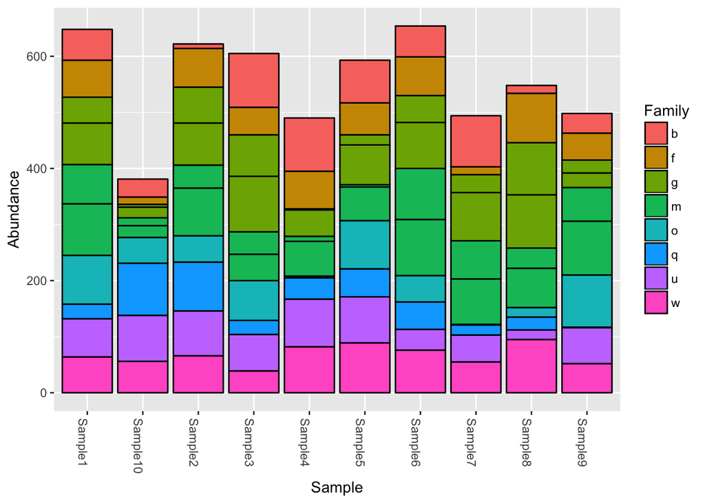

```r
plot_bar(physeq, fill = "Family")
```